# Projet final

Charlotte Verreault et Eve Martinez

2024-12-12

## Introduction

En tant que fanatiques de hockey, nous nous sommes demandé quelles sont les variables ou les caractéristiques nécessaire qui pourrait augmenter les chances d’un jeune garçon à devenir un joueur d’hockey professionnel. Pour répondre à notre question principal de recherche, nous allons analyser plusieurs sous question ; Dans quelle ville/pays devrait-il être né, quel mois de l’année devrait-il être né, quelle taille et quelle poids doit-il avoir pour mieux performer, quelle position est la plus idéale pour maximiser ses chances et enfin est-il préférable d’être droitier ou gaucher?

Pour répondre à ces questions, nous allons utiliser le jeu de donnée nhl_rosters tiré de l’article « Are Birth Dates Still Destiny for Canadian NHL Players? » de Jlaw. Ce jeu de donnée contient 18 variables et 54 883 observations. Les variables que nous avons principalement utilisées sont season, position_type, shoot_catches, height_in_centimeters, weight_in_kilograms, birth_date et birth_city. De plus, les observations commencent à partir de la saison 1917-1918 puis fini avec celle de 2023-2024 et elles comprennent tous les joueurs de toutes les équipes de la ligue national. 1- Dans quelle ville et pays devrait-il être né?

2- Quel mois de l’année devrait-il être né?

3- Quelle taille et quel poids doit-il avoir?

4- Quelle est la position sur la glace devrait-il choisir?

5- Est-il préférable d’être droitier ou gaucher?

## Importation des données

```r
library(tidyverse)
library(openintro)
library(infer)
library(parsnip)
tuesdata <- tidytuesdayR::tt_load('2024-01-09')
```

```
## ---- Compiling #TidyTuesday Information for 2024-01-09 ----
## --- There are 4 files available ---
##
##
## ── Downloading files ───────────────────────────────────────────────────────────
##
##   1 of 4: "canada_births_1991_2022.csv"
##   2 of 4: "nhl_player_births.csv"
##   3 of 4: "nhl_rosters.csv"
##   4 of 4: "nhl_teams.csv"
```

```r
nhl_rosters <- tuesdata$nhl_rosters
```

## 1 - Dans quelle ville et pays devrait-il être né?

Pour déterminer dans quelle ville un joueur de hockey, on doit trouver la ville d’où viennent le plus de joueurs. Pour ce faire, on peut simplement faire un group_by de notre variable birth_city, un count et arrangé en ordre décroissant pour avoir la ville ayant le plus de joueurs en haut. On obtient Toronto comme ville native du plus grand nombre de joueurs. On remarque aussi que les villes ayant le plus de joueurs natifs sont les grandes villes canadiennes, comme Montréal, Edmonton et Ottawa. Finalement, on peut conclure que d’être né dans une grande ville augmente les chances de devenir un joueur professionnel et le fait d’être canadiens augmente aussi les chances d’une personne.

```r
nhl_rosters %>%
  group_by(birth_city) %>%
  count(birth_city) %>%
  arrange(desc(n))
```

```
## # A tibble: 2,109 × 2
## # Groups:   birth_city [2,109]
##    birth_city     n
##    <chr>      <int>
##  1 Toronto     2843
##  2 Montréal    1949
##  3 Edmonton    1456
##  4 Ottawa      1180
##  5 Winnipeg    1172
##  6 Calgary      855
##  7 Regina       620
##  8 Saskatoon    525
##  9 Sudbury      502
## 10 London       475
## # ℹ 2,099 more rows
```

## 2 - Quel mois de l’année devrait-il être né?

Pour déterminer quel mois de l’année un joueur devrait être né pour maximiser les chances de devenir un joueur professionnel, on doit commencer par extraire nos mois de la variable birth_date avec un mutate en utilisant la fonction %m dans format que nous avons trouvé sur le site https://sqlpad.io/tutorial/extract-year-r-complete-guide/. On utilise ensuite les mêmes étapes que précédemment pour trouver quel mois de l’année le plus de joueurs professionnels sont nés. On remarque que les mois de janvier, février, mars et avril ont le plus de naissances. En allant rechercher le nombre de naissance par année, on peut observer qu’il y a plus de naissance au mois de mai, juin, juillet et août (Données obtenues sur le site de statistique Canada : https://www150.statcan.gc.ca/t1/tbl1/fr/tv.action?pid=1310041501). On peut donc conclure que d’être né au début de l’année augmente les chances d’un joueur à devenir professionnel.

```r
nhl_rosters %>%
  mutate(birth_month = birth_month <- format(nhl_rosters$birth_date, "%m")) %>%
  group_by(birth_month) %>%
  count(birth_month) %>%
  arrange(desc(n))
```

```
## # A tibble: 12 × 2
## # Groups:   birth_month [12]
##    birth_month     n
##    <chr>       <int>
##  1 01           5607
##  2 02           5321
##  3 03           5258
##  4 04           5021
##  5 05           4966
##  6 06           4660
##  7 07           4565
##  8 10           4173
##  9 09           4077
## 10 08           3850
## 11 12           3804
## 12 11           3581
```

## 3 - Quelle taille et quel poids doit-il avoir?

Pour déterminer la grandeur et la taille optimale qu’un joueur devrait avoir pour augmenter ses chances de devenir un professionnel. On peut commencer par trouver la moyenne de grandeur et de poids des joueurs canadiens qui ont joué pendant la saison 2023-2024. On a décidé de comparer seulement les joueurs canadiens, puisqu’il s’agit du pays ayant le plus de joueurs de hockey et la saison 2023-2024, puisqu’il s’agit de la plus récente. Pour ce faire, nous avons créé un nouveau data frame qui filtre nos données pour avoir seulement les joueurs canadiens de la saison 2023-2024. Ensuite, à partir de ce nouveau data frame, on peut utiliser la fonction summarize pour calculer la moyenne de la grandeur et du poids. Avec ce que l’on obtient, on peut comparer nos résultats avec la moyenne de grandeur et de poids pour la population générale canadienne pour voir s’ils ont un impact. Pour les joueurs de hockey, la moyenne de grandeur est de 186,45 cm et la moyenne de poids est de 90,95 kg. Pour la population générale canadienne, pour les hommes, la moyenne de grandeur est de 174,6 cm et la moyenne de poids est de 82,5 (Données obtenues à partir du site de Statistique Canada : https://www150.statcan.gc.ca/n1/pub/82-003-x/2011003/article/11533/tbl/tbl1-fra.htm). On remarque que les deux moyennes sont plus élevées pour les joueurs de hockey que pour la population générale. Cela nous amène à conclure que la taille et le poids ont une influence sur les chances de devenir un joueur professionnel. Plus un joueur est grand et lourd, plus il a des chances de devenir professionnel.

```r
nhl_rosters2023_2024 <- nhl_rosters %>%
  filter(birth_country == "CAN", season == "20232024")
```

```r
nhl_rosters2023_2024 %>%
  filter(!is.na(height_in_centimeters)) %>%
  summarize(mean_height = mean(height_in_centimeters))
```

```
## # A tibble: 1 × 1
##   mean_height
##         <dbl>
## 1        186.
```

```r
nhl_rosters2023_2024 %>%
  filter(!is.na(weight_in_kilograms)) %>%
  summarize(mean_weight = mean(weight_in_kilograms))
```

```
## # A tibble: 1 × 1
##   mean_weight
##         <dbl>
## 1        91.0
```

On a aussi voulu voir si la grandeur des joueurs avait augmenté au fil des années depuis le début de la ligue nationale. Pour ce faire, nous avons fait un graphique qui représente l’évolution des grandeurs des joueurs de hockey. En utilisant un geom_line avec en x les années et en y la moyenne des grandeurs, on peut facilement visualiser le tout et voir qu’il y a effectivement une évolution importante du côté de la grandeur des joueurs. Pour obtenir notre nouvelle variable des moyennes de grandeur, nous avons créé un nouveau dataframe qui contient seulement les saisons et les grandeurs et qui calcule nos moyennes de grandeurs et qui filtre pour enlever les valeurs manquantes de notre calcul de moyenne. On peut donc encore conclure que la grandeur est un facteur important qui influence beaucoup la possibilité de devenir un joueur de hockey professionnel.

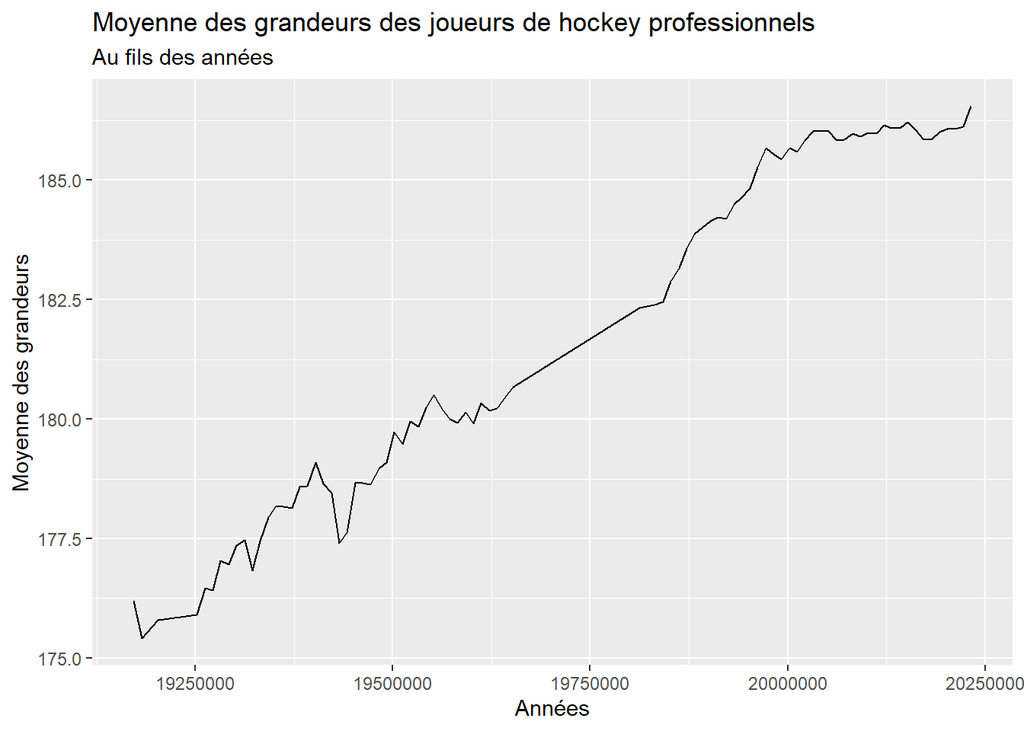

```r
nhl_rosters2 <- nhl_rosters %>%
  select(season, height_in_centimeters) %>%
  group_by(season) %>%
  summarise(mean_height = mean(height_in_centimeters)) %>%
  filter (mean_height != "NA")

ggplot(nhl_rosters2, aes(x = season, y = mean_height)) +
geom_line() +
  labs(title = "Moyenne des grandeurs des joueurs de hockey professionnels",
       subtitle = "Au fils des années",
       x = "Années",
       y = "Moyenne des grandeurs")
```

```r
nhl_rosters %>%
  specify(height_in_centimeters ~ position_type)
```

```
## Response: height_in_centimeters (numeric)
## Explanatory: position_type (factor)
## # A tibble: 54,855 × 2
##    height_in_centimeters position_type
##                    <dbl> <fct>
##  1                   183 forwards
##  2                   173 forwards
##  3                   185 forwards
##  4                   193 forwards
##  5                   185 forwards
##  6                   188 forwards
##  7                   183 forwards
##  8                   191 forwards
##  9                   178 forwards
## 10                   175 forwards
## # ℹ 54,845 more rows
```

```r
observed_f_statistic <- nhl_rosters2023_2024 %>%
  filter(!is.na(height_in_centimeters)) %>%
  specify(response = height_in_centimeters, explanatory = position_type) %>%
  hypothesize(null = "independence") %>%
  calculate(stat = "F")
```

```r
null_dist_anova <- nhl_rosters2023_2024 %>%
  filter(!is.na(height_in_centimeters)) %>%
  specify(response = height_in_centimeters, explanatory = position_type) %>%
  hypothesize(null = "independence") %>%
  generate(reps = 1000, type = "permute") %>%
  calculate(stat = "F")
```

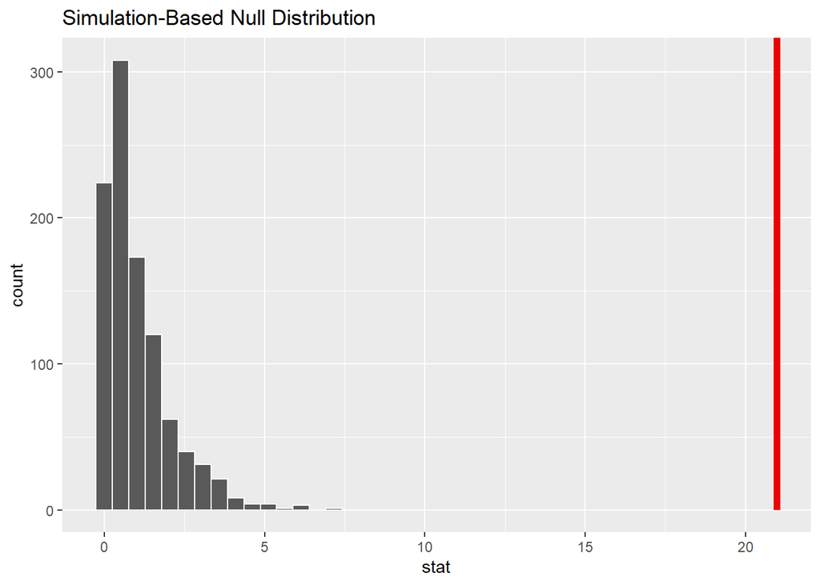

```r
null_dist_anova %>%
  visualize() +
  shade_p_value(observed_f_statistic,
                direction = "greater")
```

```r
p_value <- null_dist_anova %>%
  get_p_value(obs_stat = observed_f_statistic,
              direction = "greater")
p_value
```

```
## # A tibble: 1 × 1
##   p_value
##     <dbl>
## 1       0
```

## 4- Quelle est la position sur la glace devrait-il choisir?

Pour déterminer la position qu’un joueur devrait occuper sur la glace, on commence par trouver le top 6 des pays de naissance avec le plus de joueurs. Il est donc possible de constater qu’un grand nombre de joueurs de la LNH sont nés au Canada et aux États-Unis, ainsi qu’en Suède et ailleurs. Cela a pour but de déterminer s’il y a une corrélation entre le pays de naissance et la position que tu pourrais être plus propice à avoir. Pour bien le visualiser, on peut faire un graphique de la position des joueurs en fonction de leur pays de naissance. En prenant seulement les 6 pays plus haut, on crée un graphe à barre avec des facettes selon le pays de naissance pour pouvoir comparer chaque proportion de position selon chaque pays. Par contre, on s’est aperçu qui n’avait pas vraiment de relation entre le pays et la position. Cela signifie que peut importe le joueur vient d’où il a autant de chance de devenir attaquant, défenseur ou gardien de but. Le pays ne va rien changer. Cependant, on remarque que, dans tous les pays, il y a une majorité de joueurs qui sont attaquants, puisque, bien évidemment, une équipe contient plus d’attaquants que les autres positions. Il est donc possible de conclure que le jeune garçon a plus de chance de jouer professionnellement s’il est attaquant, et ce, peu importe, il vient de quel pays.

```r
nhl_rosters %>%
  select(position_type, birth_country) %>%
  count(birth_country) %>%
  arrange(desc(n)) %>%
  slice(1:6)
```

```
## # A tibble: 6 × 2
##   birth_country     n
##   <chr>         <int>
## 1 CAN           36405
## 2 USA            8906
## 3 SWE            2423
## 4 CZE            1701
## 5 RUS            1634
## 6 FIN            1362
```

```r
nhl_rosters34 <- nhl_rosters %>%
  filter(birth_country == c("CAN", "USA", "SWE", "CZE", "RUS", "FIN"))
```

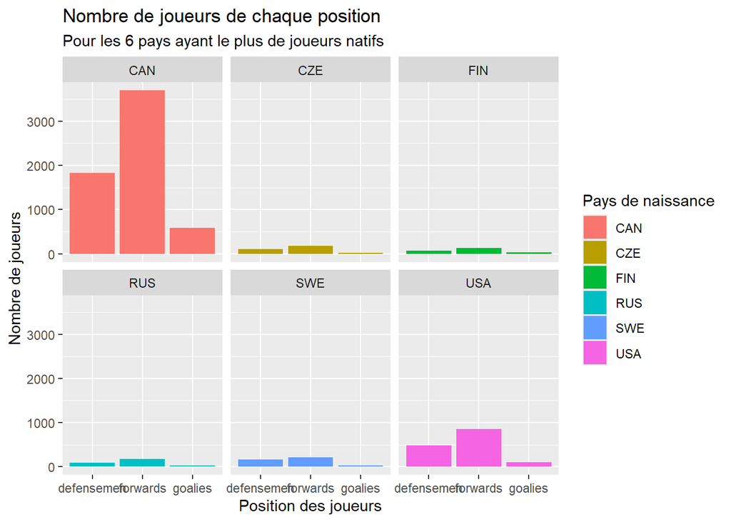

```r
ggplot(nhl_rosters34, aes(x = position_type, fill = birth_country)) +
  geom_bar() +
  facet_wrap(~birth_country) +
  labs(title = "Nombre de joueurs de chaque position",
       subtitle = "Pour les 6 pays ayant le plus de joueurs natifs",
       x = "Position des joueurs",
       y = "Nombre de joueurs",
       fill = "Pays de naissance")
```

## 5 - Est-il préférable d’être droitier ou gaucher?

Pour finir, il faut savoir si notre jeune joueur dit être gaucher ou droitier. Pour ce faire, on doit utiliser la fonction count pour compter la proportion de gaucher et droitier des joueurs de la ligne national. Il faut commencer par extraire les valeurs manquantes, car nous n’avons pas toutes les données. À partir de ce tableau, il est possible de remarquer qu’il y a beaucoup plus de gauchers que de droitier, ce qui est une grande surprise. En effet, selon Radio-Canada (Données obtenues : https://ici.radio-canada.ca/ohdio/premiere/emissions/moteur-de-recherche/segments/rattrapage/1880298/pourquoi-il-y-a-moins-gauchers-que-droitiers) il y aurait seulement entre 3% et 15% de la population qui serait gauchère. Ce qui est vraiment une minorité. Par contre, dans la LNH, ce n’est pas la même réalité. On peut donc conclure qu’il vaut mieux être gaucher pour maximiser les chances de devenir un joueur de hockey professionnel.

```r
nhl_rosters %>%
  filter(!is.na(shoots_catches)) %>%
  group_by(shoots_catches) %>%
  count(shoots_catches)
```

```
## # A tibble: 2 × 2
## # Groups:   shoots_catches [2]
##   shoots_catches     n
##   <chr>          <int>
## 1 L              35973
## 2 R              18625
```

## Conclusion

Maintenant, il est possible de savoir ce que les jeunes joueurs doivent faire pour atteindre leur plus grand rêve : devenir un joueur de la LNH. Il est important de naître dans une grande ville canadienne au mois de janvier ou février, d’être plus grand et plus lourd que la moyenne, de pratiquer la position d’attaquant et enfin d’être un gaucher.